# Packages and DESeq2

Tarık KIRLIOĞLU

2024-06-04

## Packages and DESeq2

R paketleri, R fonkdiyonlarının, kodlarının ve verilerinin koleksiyonudur. `library`dizininde saklanır. Kurulum ile yüklenen paketler mevcuttur. İhtiyaç duyulduğunda ek paketler yüklemek mümkündür. R paketlerinin yer aldığı dizini bulmak için `.libPaths()` fonksiyonu kullanılır. Kurulu tüm paketlerin listesini almak için ise `library()` fonksiyonu kullanılır.

R ortamına yeni paketler eklenmek isteniyorsa birden fazla depodan bu işlem gerçekleştirilebilir. Kullanıcıların ve geliştiricilerin kullandığı depolar mevcuttur. Bunlar çevrimiçi ve erişilebilirdir. Sıklıkla kullanılan depolar; CRAN (Kapsamlı R Arşiv Ağı), Biocunductor (Biyoinformatik için özelleşmiş bir depodur) ve Github (Açık kaynaklı projelerin yer aldığı popüler depodur.)

R paketlerini CRAN’dan yüklemek için `install.packages("package_name")` kullanılır.

Bicunductor paketlerini kurmak ve yüklemek için `BiocManager` paketi kullanılır. Bu paket `install.packages("BiocManager")` komutu ile yüklenir. Yükleme tamamlandıktan sonra Biocunductor paketlerini yüklemek için `BiocManager::install("DESeq2")` komutu kullanılır. Eğer hata ile karşılaşılması durumunda Biocunductor web sayfasından indirilmek istenen paket ulaşılarak yükleme için geçerli komut ile yükleme gerçekleştirilebilir.

Github üzerinden bir yükleme yapılmak isteniyorsa; `install.packages("devtools")` komutu ile devtools yüklenir. Daha sonra yüklenmek istenen paketler; `devtools::install_github("tidyverse/tidyverse")` komutu kullanılarak yükleme gerçekleştirilebilir.

Bilgisayarınızda hangi paketlerin yüklü olduğunu kontrol etmek için; `installed.pasckages()` komutu kullanılır.

Bilgisayarınızda var olan tüm paketleri güncellemek için; `update.packages()` komutu kullanılır.

Belirli bir paketi güncellemek için; `install.packages("package name")` komutu kullanılır.

## Differantial Gene Expression Analysis with DESeq2

Diferensiyel olarak ifade edilen genlerin analizine geçmeden önce analiz aşamasında kullanılan paketlerin yüklenmesi gerekmektedir. Bu paketleri yukarıda ifade edilen şekilde yüklenebilir.

Paketler indirildikten sonra çalışılacak paketlerin R ortamına yüklenmesi için ; `library("package_name")` kullanılır.

```r
library(DESeq2)
```

```r
library(pheatmap)
library(ggplot2)
library(RColorBrewer)
library(tidyverse)
library(EnhancedVolcano)
```

Bu işlemden sonra çalışılacak klasöre gitmek için `setwd()` kullanılabilir. Ayrıca `Session`, `Set Working Directory`, `Choose Directory` seçildikten sonra çalışılacak klasör seçilebilir.

```r
setwd("C:/Users/Honor/Desktop/deseq")
```

Analizin ilk adımı olarak `counts` dosyasının yüklenmesi gerekir. Counts dosyası RNA-seq veri analizi sonucunda elde edilen sayım matrisidir. Dosya formatı genellikle `.csv` uzantılı kullanılır.

```r
counts <- read.csv("counts.csv",
                   row.names = 1,
                   sep = ",",
                   header = T)
head(counts)
```

```
##       RIP1_KO_aTreg RIP1_KO_rTreg WT_aTreg WT_rTreg
## Gnai3          3540          3273     3547     3865
## Cdc45           641           745      187      327
## Scml2             2            11        4        5
## Apoh              0             0        6        2
## Narf           1101          1064     1145     1268
## Cav2             22            15       18        5
```

Bir sonraki adımda `col_data` dosyasının yüklenmesi gerekir.col_data dosyası ise örnekler hakkında bilgiler içermektedir.

```r
col_data <- data.frame(condition=c("treated", "treated", "control", "control"))

rownames(col_data) <- colnames(counts)

head(col_data)
```

```
##               condition
## RIP1_KO_aTreg   treated
## RIP1_KO_rTreg   treated
## WT_aTreg        control
## WT_rTreg        control
```

Sütun isimleri ile sıra isimlerinin aynı olması gerekmektedir. Bunun için sıra isimlerinin sutün isimleri ile eşleşip eşleşmediğini sorabiliriz.

```r
all(colnames(counts)==rownames(col_data))
```

```
## [1] TRUE
```

Bu işlemden sonra DESeq objesi yani sayım matrislerinin girişini oluşturmak gerekmektedir. Bu `DESeqDataSetFromMatrix()` fonksiyonu ile gerçekleştirilir. Bu objeye `counts` ve `col_data` verilerini girdi olarak sunarız.

```r
dds <- DESeqDataSetFromMatrix(countData =counts,
                              colData = col_data,
                              design = ~condition)
dds
```

```
## class: DESeqDataSet
## dim: 19044 4
## metadata(1): version
## assays(1): counts
## rownames(19044): Gnai3 Cdc45 ... A930007A09Rik Gm7592
## rowData names(0):
## colnames(4): RIP1_KO_aTreg RIP1_KO_rTreg WT_aTreg WT_rTreg
## colData names(1): condition
```

Bu işlemden sonra filtreleme işlemi gerçekleştirilir. Bunun amacı 10’dan saha az sayım içeren sıraların kaldırılmasını amaçlamaktadır.

```r
keep <- rowSums(counts(dds)) >= 10
dds <- dds[keep,]
```

Hangi koşula göre karşılaştırma yapmak istediğimizi belirtmemiz gerekir. Bunun için factor level seçimi yapmalıyız. `relevel()` komutu ile seçim yapabiliriz. Eğer seçim yapmazsak R, alfabetik sıralamaya göre referans seçimini gerçekleştirir.

```r
dds$condition <- relevel(dds$condition, ref = "control")
```

Artık `DESeq()` fonksiyonunu çalıştırmaya hazırız. Bu fonksiyon ile beraber hesaplamalar gerçekleştirildikten sonra logFC deperleri ve bir dizi istatistiksel değerlere ulaşabiliriz.

```r
dds <- DESeq(dds)
res <- results(dds)
res
```

```
## log2 fold change (MLE): condition treated vs control
## Wald test p-value: condition treated vs control
## DataFrame with 15121 rows and 6 columns
##                 baseMean log2FoldChange     lfcSE      stat      pvalue
##                <numeric>      <numeric> <numeric> <numeric>   <numeric>
## Gnai3         3541.99404      0.0766579  0.122563  0.625457 5.31671e-01
## Cdc45          490.66712      1.6353340  0.292738  5.586345 2.31898e-08
## Scml2            5.64308      0.7577726  1.525876  0.496615 6.19461e-01
## Narf          1139.36027      0.0427442  0.149663  0.285603 7.75182e-01
## Cav2            15.18587      0.8757229  0.992460  0.882376 3.77574e-01
## ...                  ...            ...       ...       ...         ...
## Lhb              2.82719       2.347157  2.088040  1.124096    0.260972
## 1700094D03Rik  141.87846       0.237388  0.329768  0.719865    0.471608
## Shld3          122.33758       0.295258  0.365799  0.807158    0.419575
## A930007A09Rik   11.89279       0.880965  0.972477  0.905899    0.364990
## Gm7592           8.79135       0.445059  1.109195  0.401245    0.688240
##                      padj
##                 <numeric>
## Gnai3         7.49629e-01
## Cdc45         1.13976e-06
## Scml2                  NA
## Narf          8.97396e-01
## Cav2          6.24965e-01
## ...                   ...
## Lhb                    NA
## 1700094D03Rik    0.706630
## Shld3            0.664767
## A930007A09Rik          NA
## Gm7592                 NA
```

**Not:** Eğer sistem çökerse bu teknik tekrarı olmamasından dolayı kaynaklanmaktadır. DESeq2 ile analiz yapmak için örneklerin teknik tekrarlarının olması gerekmektedir.

Analiz sonucunda özet bilgi almak için `summary(res)` fonksiyonunu kullanabiliriz.

```r
summary(res)
```

```
##
## out of 15121 with nonzero total read count
## adjusted p-value < 0.1
## LFC > 0 (up)       : 1493, 9.9%
## LFC < 0 (down)     : 1157, 7.7%
## outliers [1]       : 0, 0%
## low counts [2]     : 2932, 19%
## (mean count < 15)
## [1] see 'cooksCutoff' argument of ?results
## [2] see 'independentFiltering' argument of ?results
```

pvalue’ye göre sıralama yapmasını isteyebiliriz.

```r
resOrdered <- res[order(res$pvalue),]

head(resOrdered)
```

```
## log2 fold change (MLE): condition treated vs control
## Wald test p-value: condition treated vs control
## DataFrame with 6 rows and 6 columns
##         baseMean log2FoldChange     lfcSE      stat      pvalue        padj
##        <numeric>      <numeric> <numeric> <numeric>   <numeric>   <numeric>
## Xist    3079.579      -10.32276  0.501435 -20.58641 3.63283e-94 4.42806e-90
## Lgals3  1134.900        2.78847  0.205899  13.54293 8.72340e-42 5.31647e-38
## Igkc     190.335        3.88026  0.361072  10.74647 6.15710e-27 2.50163e-23
## Gbp2    3564.635        1.57331  0.152800  10.29653 7.30478e-25 2.22595e-21
## Iigp1   3006.520        2.02113  0.201894  10.01086 1.36566e-23 3.32921e-20
## Lgals1  8111.696        1.72780  0.179952   9.60144 7.88374e-22 1.46372e-18
```

DESeq objesi eğer istenirse dataframe’e çevrilebilir.Bunun için `as.data.frame()` fonksiyonu kullanılır.

```r
res_deseq <- as.data.frame(res)
class(res_deseq)
```

```
## [1] "data.frame"
```

```r
head(res_deseq)
```

```
##          baseMean log2FoldChange     lfcSE       stat       pvalue         padj
## Gnai3 3541.994039     0.07665794 0.1225632  0.6254567 5.316714e-01 7.496289e-01
## Cdc45  490.667119     1.63533400 0.2927377  5.5863453 2.318979e-08 1.139759e-06
## Scml2    5.643076     0.75777261 1.5258758  0.4966149 6.194607e-01           NA
## Narf  1139.360268     0.04274415 0.1496627  0.2856033 7.751820e-01 8.973956e-01
## Cav2    15.185875     0.87572287 0.9924603  0.8823757 3.775737e-01 6.249654e-01
## Klf6  5017.585237    -0.43976994 0.1125339 -3.9078875 9.310662e-05 1.349437e-03
```

Bir takım özel genlerin sorgusu yapılabilir. Örneğin Xist geni üzerine bir tarama gerçekleştirelim. Gene ulaşmak için kapalı parantez kullanılır.

```r
res_deseq["Xist",]
```

```
##      baseMean log2FoldChange     lfcSE      stat       pvalue        padj
## Xist 3079.579      -10.32276 0.5014355 -20.58641 3.632833e-94 4.42806e-90
```

**Not:** Şunu söyleyebiliriz ki Xist geni kontrole kıyasla aşağı regüle edilmiştir. Yani tedavi altında ifadesinde bir artış söz konusu değildir.

Sayım matrislerinin normalize edilmiş hali elde edilebilir. Bunun için ``counts()` fonksiyonu kullanılır.

```r
normalized_counts <- counts(dds, normalized=T)
head(normalized_counts)
```

```
##       RIP1_KO_aTreg RIP1_KO_rTreg    WT_aTreg    WT_rTreg
## Gnai3   3662.397688    3609.73400 3310.909630 3584.934833
## Cdc45    663.162971     821.64737  174.553172  303.304965
## Scml2      2.069151      12.13171    3.733758    4.637691
## Narf    1139.067755    1173.46684 1068.788138 1176.118336
## Cav2      22.760664      16.54324   16.801910    4.637691
## Klf6    4313.145751    4204.18760 5804.126326 5748.881267
```

Elde edilen sonuçlar `.csv` uzantılı bir şekilde kaydedilebilir.Bunun için `write.csv()` fonksiyonu kullanılır.

```r
write.csv(res_deseq, "res_deseq.csv")
write.csv(normalized_counts, "normalize_counts.csv")
```

## Görselleştirme

DESeq analizi ile beraber bir çok veri görselleştirmesi yapılabilir. Burada DESeq2 paketinin sunmuş olduğu bir çok fonksiyon kullanılabilir. Aynı zamanda ggplot, pheatmap gibi paketler de kullanılabilir.

### 1)PCA (Principal Component Analysis)

Temel bileşen analizi, DESeq2 paketinin sunmuş olduğu fonksiyonlar ile gerçekleştirilebilir.PCA çok boyutlu veri setlerinin düşük boyuta indirgenmesidir. Bunu, çok büyük veri setlerinin izdüşümü olarak düşünebiliriz. Öncelikli olarak pca grafiğini oluşturabilmek için variance stabilizing transformation işlemini gerçekleştirmemiz gerekir. Bunu `vst()` fonksiyonu ile yapabiliriz.Daha sonra transforme edilen değerler üzerinden pca grafiği oluşturabiliriz. Sonuç olarak, benzer koşullar altında olan örneklerin beraber kümelendiğini görmek isteriz. Örneklerin bireysel olarak farklı yerlerde bulunması pek istenen bir durum değildir.

```
## using ntop=500 top features by variance
```

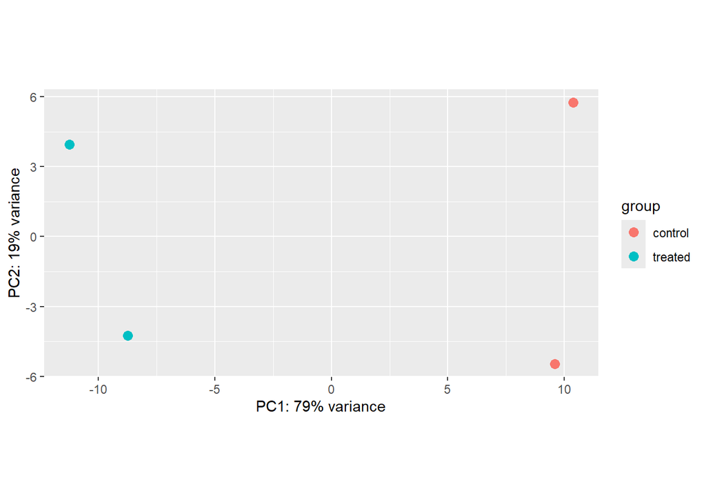

```r
vstdata <- vst(dds,
               blind = F)
plotPCA(vstdata,
        intgroup="condition")
```

### 2)MA Grafiği

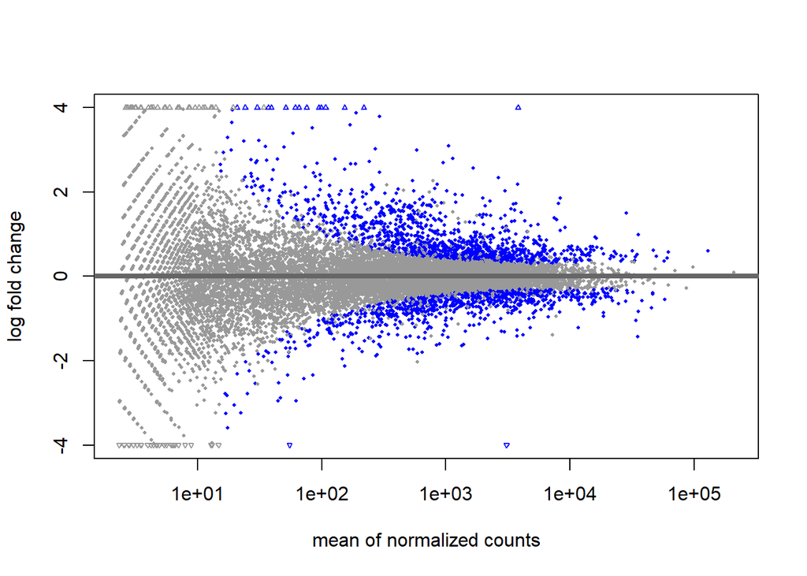

```r
plotMA(res, alpha=0.05)
```

### 3) ggplot ile MA Grafiği

Bu görselleştirme de ggplot paketini kullanarak bir MA grafiği çizdirelim. Bunun için öncelikle anlamlı olan genleri belirtmek için yeni bir sütün oluşturulalım. Bunu `ifelse()` fonksiyonu ile yapabiliriz.

```r
res$signaficant <- ifelse(res$pvalue <= 0.05, "yes", "no")
head(res)
```

```
## log2 fold change (MLE): condition treated vs control
## Wald test p-value: condition treated vs control
## DataFrame with 6 rows and 7 columns
##         baseMean log2FoldChange     lfcSE      stat      pvalue        padj
##        <numeric>      <numeric> <numeric> <numeric>   <numeric>   <numeric>
## Gnai3 3541.99404      0.0766579  0.122563  0.625457 5.31671e-01 7.49629e-01
## Cdc45  490.66712      1.6353340  0.292738  5.586345 2.31898e-08 1.13976e-06
## Scml2    5.64308      0.7577726  1.525876  0.496615 6.19461e-01          NA
## Narf  1139.36027      0.0427442  0.149663  0.285603 7.75182e-01 8.97396e-01
## Cav2    15.18587      0.8757229  0.992460  0.882376 3.77574e-01 6.24965e-01
## Klf6  5017.58524     -0.4397699  0.112534 -3.907888 9.31066e-05 1.34944e-03
##       signaficant
##       <character>
## Gnai3          no
## Cdc45         yes
## Scml2          no
## Narf           no
## Cav2           no
## Klf6          yes
```

Bu işlemden sonra ggplot ile görselleştirme yapabiliriz.

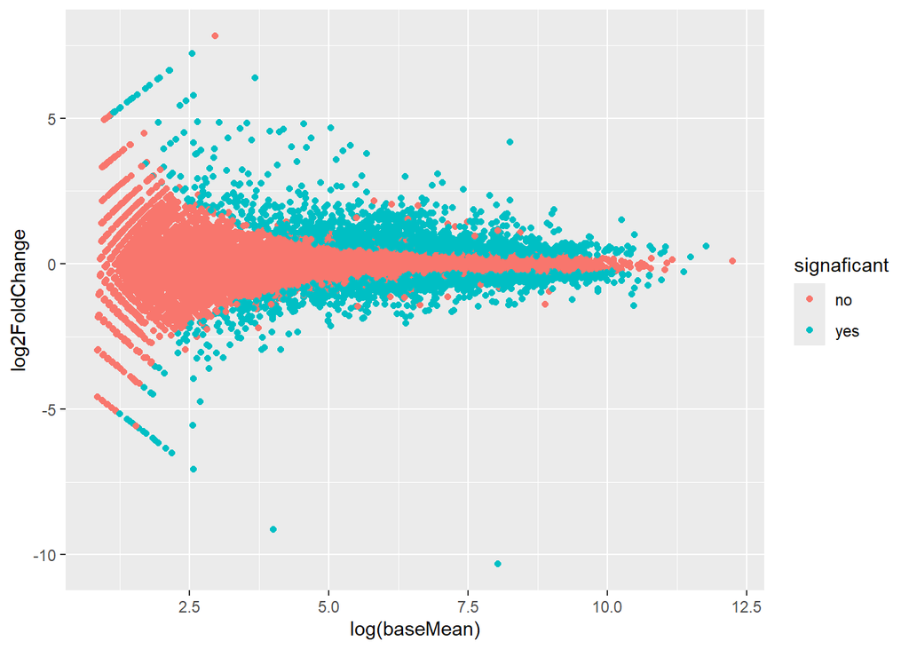

```r
res %>% ggplot(aes(x=log(baseMean), y=log2FoldChange, color= signaficant)) +
  geom_point()
```

### 5)ggplot ile Volcano Grafiği

Volcano grafiği, MA grafiğine benzer şekilde diferensiyal olarak ifade edilen genlerin yorumlanmasında kullanılır.

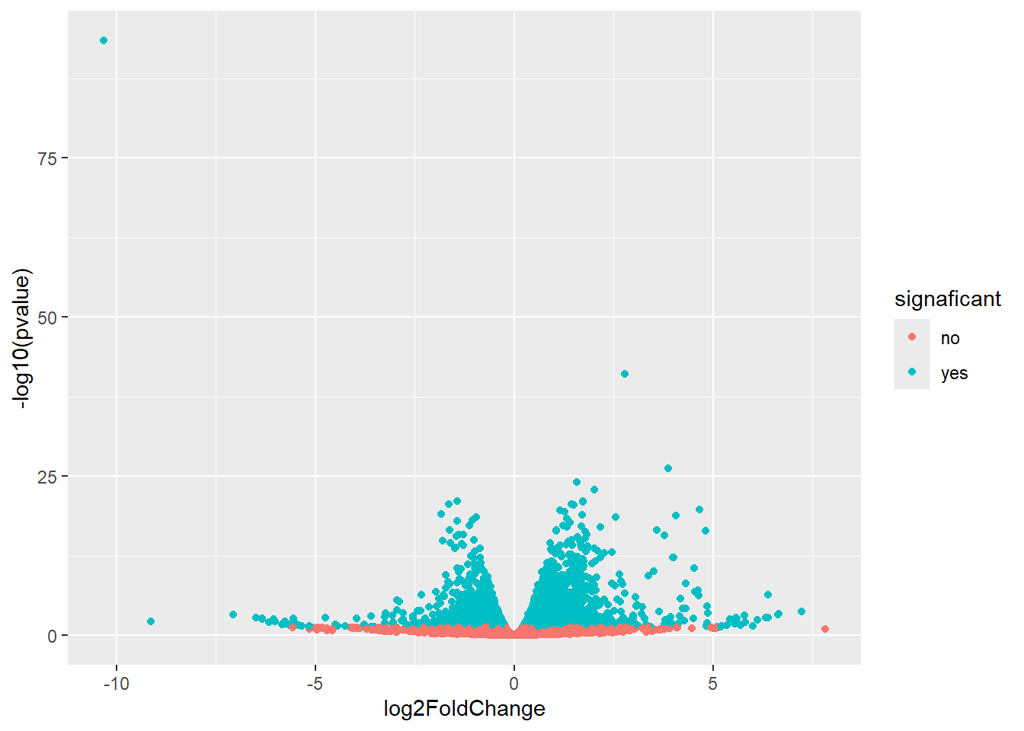

```r
res %>% ggplot(aes(x=log2FoldChange, y=-log10(pvalue), color= signaficant)) +
  geom_point()
```

### 6)Enhanced Volcano Plot

Enhanced Volcano ile kolayca volcano plot çizdirelim.

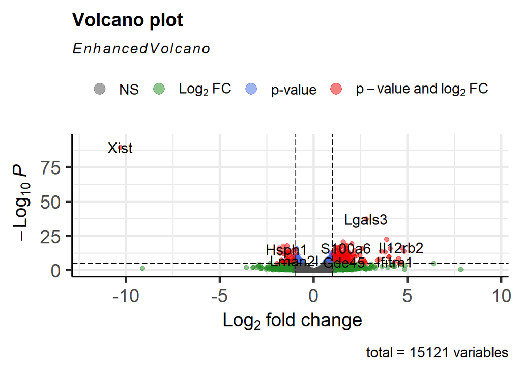

```r
EnhancedVolcano(res_deseq, x="log2FoldChange", y="padj", lab = rownames(res_deseq))
```

### 7)pheatmap

Şimdi diferensiyal olarak önemli olan genler ile heatmap grafiği çizdirelim. Bunun için öncelikle res objemizden yalnızca anlamlı yani p-value değeri 0.05 ve 0.05’den küçük genleri seçmeliyiz. Bu işlem için `subset()` fonksiyonunu kullanabiliriz.

```r
significant <- subset(res_deseq, subset=res$pvalue <= 0.05)
head(significant)
```

```
##          baseMean log2FoldChange     lfcSE      stat       pvalue         padj
## Cdc45    490.6671      1.6353340 0.2927377  5.586345 2.318979e-08 1.139759e-06
## Klf6    5017.5852     -0.4397699 0.1125339 -3.907888 9.310662e-05 1.349437e-03
## Cox5a   1200.3297      0.7407822 0.1567733  4.725182 2.299095e-06 6.039585e-05
## Gna12    524.0838     -0.4535214 0.2226250 -2.037154 4.163463e-02 1.590861e-01
## Tspan32 5210.7301     -0.3697105 0.1502878 -2.460016 1.389308e-02 7.190776e-02
## Scpep1   531.0394      1.6549563 0.2073512  7.981416 1.446635e-15 3.903565e-13
```

İkinci işlem olarak normalize edilmiş sayımlar ile diferensiyal olarak anlamlı genleri tek bir veri altında toplamamız gerekir.Bunun için iki veri yapısını birleştirmek için `merge()` fonksiyonu kullanılır.

```r
all_sig <- merge(normalized_counts, significant, by=0)
head(all_sig)
```

```
##       Row.names RIP1_KO_aTreg RIP1_KO_rTreg  WT_aTreg   WT_rTreg  baseMean
## 1 1110004F10Rik     1513.5841     1431.5413 1187.3349 1150.14727 1320.6519
## 2 1110032F04Rik      232.7795      350.7166  351.9067  604.75485  385.0394
## 3 1110059E24Rik      317.6147      435.6385  242.6942  271.76867  316.9290
## 4 1500009L16Rik      525.5644      462.1077  117.6134   62.14505  291.8576
## 5 1500011B03Rik      587.6390      495.1942  354.7070  392.34862  457.4722
## 6 1600014C10Rik     1651.1827     1826.3732 2296.2610 2403.25127 2044.2670
##   log2FoldChange     lfcSE      stat       pvalue         padj
## 1      0.3334785 0.1405343  2.372933 1.764745e-02 8.614527e-02
## 2     -0.7139701 0.3306975 -2.158982 3.085154e-02 1.288723e-01
## 3      0.5493912 0.2582373  2.127467 3.338132e-02 1.360364e-01
## 4      2.4583658 0.3296309  7.457935 8.788886e-14 1.447672e-11
## 5      0.5358782 0.2069587  2.589301 9.617102e-03 5.429498e-02
## 6     -0.4345999 0.1362953 -3.188663 1.429322e-03 1.243647e-02
```

Hazırlanan all_sig verisinden sayımlar tekrar çekilir. Bunun için indekleme kullanılır.

```r
counts_sig_n <- all_sig[,2:5]
head(counts_sig_n)
```

```
##   RIP1_KO_aTreg RIP1_KO_rTreg  WT_aTreg   WT_rTreg
## 1     1513.5841     1431.5413 1187.3349 1150.14727
## 2      232.7795      350.7166  351.9067  604.75485
## 3      317.6147      435.6385  242.6942  271.76867
## 4      525.5644      462.1077  117.6134   62.14505
## 5      587.6390      495.1942  354.7070  392.34862
## 6     1651.1827     1826.3732 2296.2610 2403.25127
```

count_sig_n verisine row names eklemek için `row.names()` fonksiyonu kullanılır.

```r
row.names(counts_sig_n) <- all_sig$Row.names

head(counts_sig_n)
```

```
##               RIP1_KO_aTreg RIP1_KO_rTreg  WT_aTreg   WT_rTreg
## 1110004F10Rik     1513.5841     1431.5413 1187.3349 1150.14727
## 1110032F04Rik      232.7795      350.7166  351.9067  604.75485
## 1110059E24Rik      317.6147      435.6385  242.6942  271.76867
## 1500009L16Rik      525.5644      462.1077  117.6134   62.14505
## 1500011B03Rik      587.6390      495.1942  354.7070  392.34862
## 1600014C10Rik     1651.1827     1826.3732 2296.2610 2403.25127
```

Artık heatmap oluşturmak için verimiz hazır. Heatmap çizdirmek için `pheatmap()` fonksiyonu kullanılır.

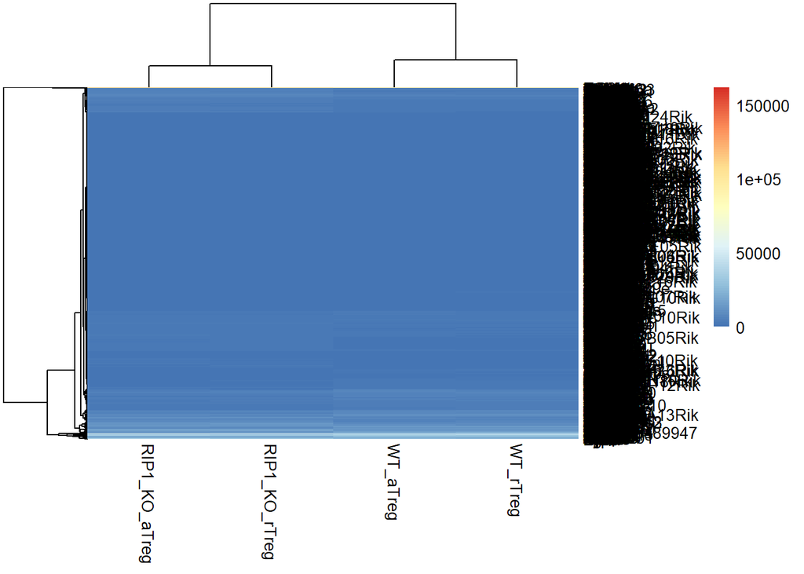

```r
pheatmap(counts_sig_n)
```

Çıkan görsel göze hoş gelmediği için sayımlar log formuna çevrilir. Aynı zamanda `scale` parametresini kullanarak sütün veya sıraya göre ifade seviyesini karşılaştırmasını isteyebiliriz. `show_rownames` parametresini `FALSE` yaparak gen isimlerini kaldırabiliriz.

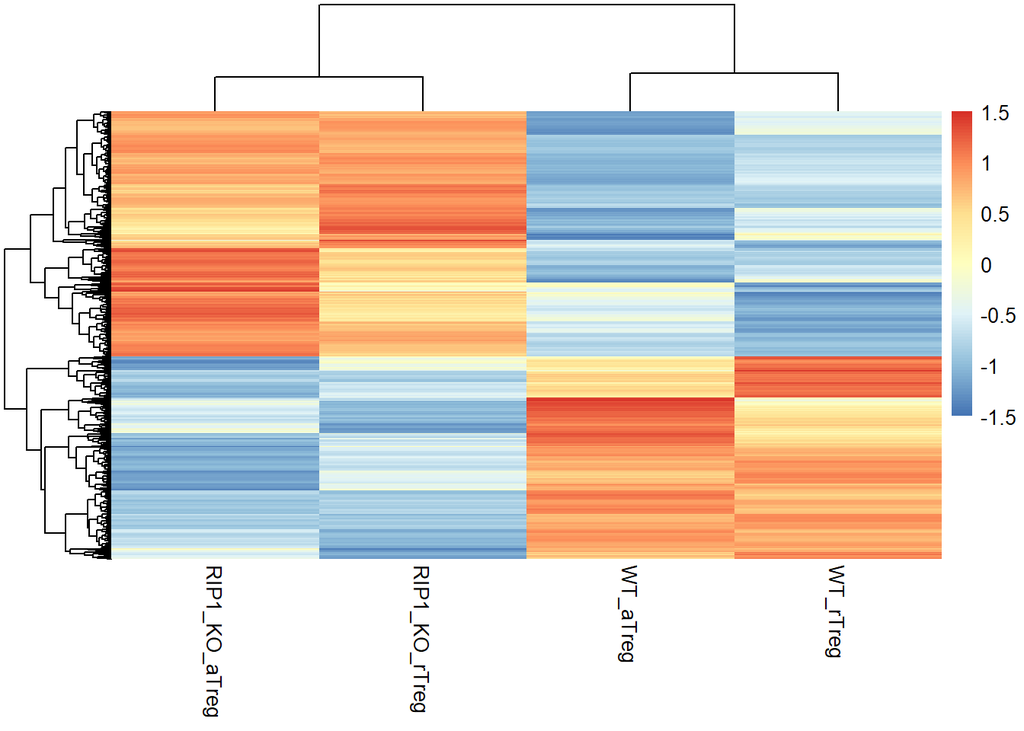

```r
pheatmap(log2(counts_sig_n + 1), scale = "row", show_rownames = F)
```

Son olarak, istenildiği taktirde `treeheight_row` ve `treeheight_col` parametrelerini kullanarak ağaçları kaldırabiliriz.

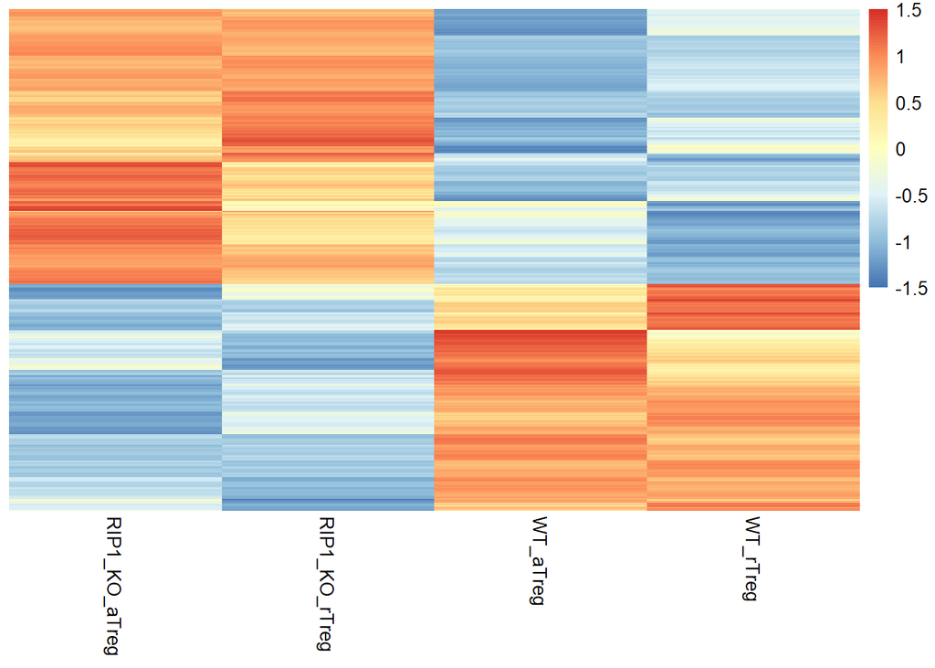

```r
pheatmap(log2(counts_sig_n + 1),
         scale = "row",
         show_rownames = F,
         treeheight_row = 0,
         treeheight_col = 0)
```

### 6)pheatmap ile TOP20 genin heatmap grafiği

Top 20 gen, pvalue değerlerine göre yapılan sıralama sonucunda seçilir. Daha sonra 20 genin sayım matrisleri seçilir ve row.names eşleşmesi gerçekleştirilir.

```r
top20 <- head(all_sig[order(all_sig$pvalue),],20)
top20_counts <- top20[ ,2:5]
row.names(top20_counts) <- top20$Row.names
head(top20_counts)
```

```
##        RIP1_KO_aTreg RIP1_KO_rTreg   WT_aTreg  WT_rTreg
## Xist        4.138302      5.514412 6492.07118 5816.5915
## Lgals3   2294.688721   1670.866794  277.23151  296.8122
## Igkc      310.372685    402.552066   28.93662   19.4783
## Gbp2     4763.186145   5909.243751 1799.67121 1786.4384
## Iigp1    3909.661260   5739.399866 1132.26202 1244.7562
## Lgals1  13840.552617  11081.762078 3271.70517 4252.7623
```

Son olarak, top 20 genin heatmap grafiğini görmek için `pheatmap()` fonksiyonu kullanılır.

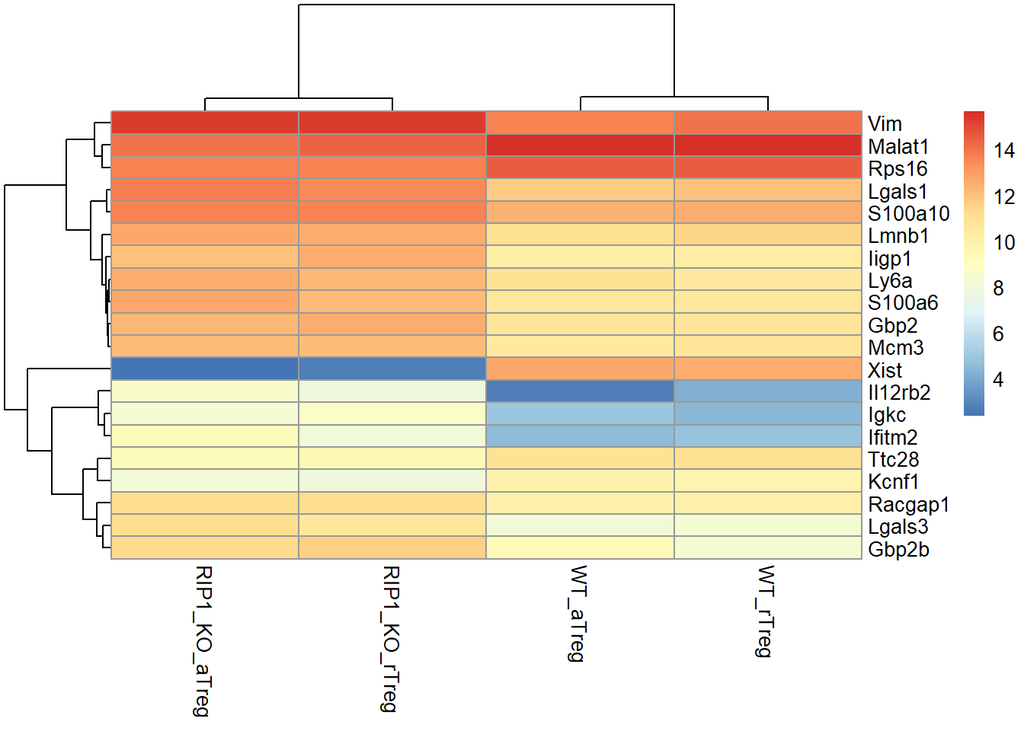

```r
pheatmap(log2(top20_counts + 1))
```